# Week 4 Class Activity

## Load Necessary Libraries

```r
library(ggplot2) #for graphing
library(viridis) #color palettes
library(MetBrewer) #color palettes
library(tidyverse) #for data cleaning
```

## Load in Dataset

```r
mydata <- read.csv("../Data/ch7ds1.csv")
head(mydata)
```

```
##   Income Education
## 1  36577        11
## 2  54365        12
## 3  33542        10
## 4  65654        12
## 5  45765        11
## 6  24354         7
```

Calculate the correlation coefficient using the cor function.

```r
cor(mydata$Income, mydata$Education)
```

```
## [1] 0.5744407
```

Plotting the correlation

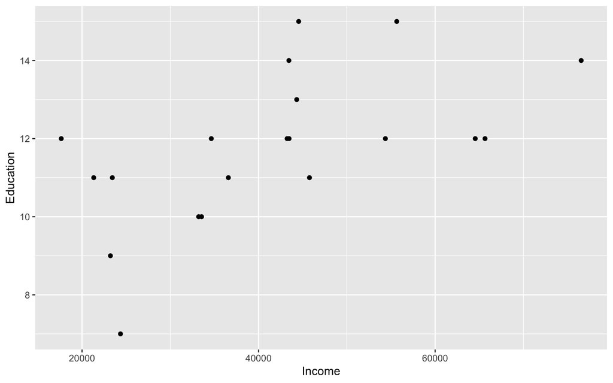

```r
ggplot(mydata, aes(Income, Education)) +
  geom_point()
```

Adding a regression line

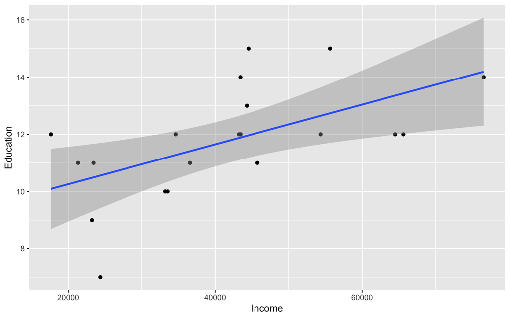

```r
ggplot(mydata, aes(Income, Education)) +
  geom_point() +
  geom_smooth(method = "lm")
```

Create three vectors using fake data:

```r
IceCreamConsumption <- c(3.4, 5.4, 6.7, 2.3, 5.3, 4.4, 5.1, 2.1, 3.2, 2.2)

CrimeRate <- c(62, 98, 76, 45, 94, 88, 90, 68, 76, 35)

AverageTemperature <- c(88, 89, 65, 44, 89, 62, 91, 33, 46, 41)

IceCream <- data.frame(IceCreamConsumption, CrimeRate, AverageTemperature)
```

Load the library named ppcor

```r
library(ppcor)
```

First, let’s run a regular correlation:

```r
cor(IceCream)
```

```
##                     IceCreamConsumption CrimeRate AverageTemperature
## IceCreamConsumption           1.0000000 0.7429317          0.7038434
## CrimeRate                     0.7429317 1.0000000          0.6552779
## AverageTemperature            0.7038434 0.6552779          1.0000000
```

Now, let’s run a partial correlation:

```r
pcor(IceCream)
```

```
## $estimate
##                     IceCreamConsumption CrimeRate AverageTemperature
## IceCreamConsumption           1.0000000 0.5250130          0.4291989
## CrimeRate                     0.5250130 1.0000000          0.2783881
## AverageTemperature            0.4291989 0.2783881          1.0000000
##
## $p.value
##                     IceCreamConsumption CrimeRate AverageTemperature
## IceCreamConsumption           0.0000000 0.1466822          0.2489876
## CrimeRate                     0.1466822 0.0000000          0.4682340
## AverageTemperature            0.2489876 0.4682340          0.0000000
##
## $statistic
##                     IceCreamConsumption CrimeRate AverageTemperature
## IceCreamConsumption            0.000000 1.6320801          1.2572421
## CrimeRate                      1.632080 0.0000000          0.7668606
## AverageTemperature             1.257242 0.7668606          0.0000000
##
## $n
## [1] 10
##
## $gp
## [1] 1
##
## $method
## [1] "pearson"
```

By indexing, you can show only the correlation estimates:

```r
pcor(IceCream)$estimate
```

```
##                     IceCreamConsumption CrimeRate AverageTemperature
## IceCreamConsumption           1.0000000 0.5250130          0.4291989
## CrimeRate                     0.5250130 1.0000000          0.2783881
## AverageTemperature            0.4291989 0.2783881          1.0000000
```

Another correlation example:

```r
rel.data <- read.csv("../Data/ch17ds1.csv")
head(rel.data)
```

```
##   Qual.Marriage Qual.PC
## 1             2    58.7
## 2             6    55.3
## 3             6    61.8
## 4            10    49.5
## 5             3    64.5
## 6             4    61.0
```

Correlation between marriage quality and parent-child interaction quality:

```r
cor(rel.data)
```

```
##               Qual.Marriage     Qual.PC
## Qual.Marriage    1.00000000 -0.09996305
## Qual.PC         -0.09996305  1.00000000
```

```r
cor(rel.data$Qual.Marriage, rel.data$Qual.PC)
```

```
## [1] -0.09996305
```

A scatterplot of the relationship data:

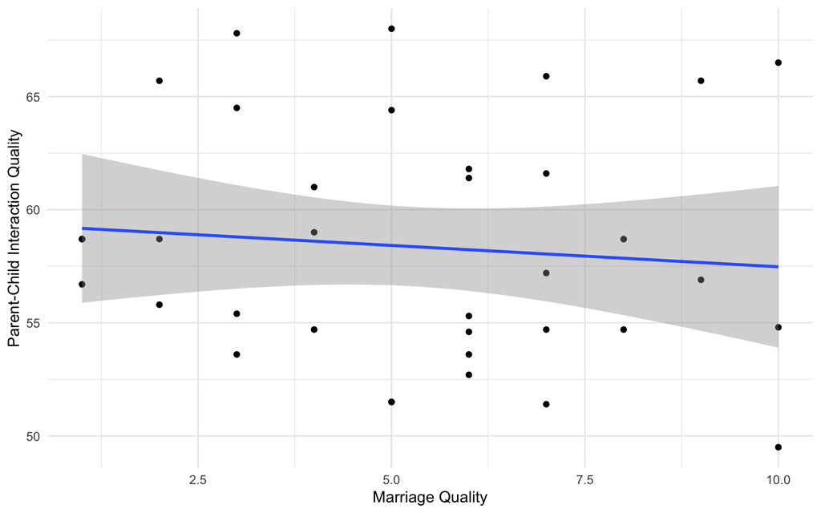

```r
ggplot(rel.data, aes(Qual.Marriage, Qual.PC)) +
  geom_point() +
  geom_smooth(method = "lm") +
  theme_minimal() +
  labs(x = "Marriage Quality", y = "Parent-Child Interaction Quality")
```

## Correlations with p-values

P-Value rule of thumb: < 0.05, then it IS statistically significant Smaller the p value is, the better.

p .001 is more significant than 0.045.

```r
cor.test(rel.data$Qual.Marriage, rel.data$Qual.PC)
```

```
##
##  Pearson's product-moment correlation
##
## data:  rel.data$Qual.Marriage and rel.data$Qual.PC
## t = -0.58581, df = 34, p-value = 0.5619
## alternative hypothesis: true correlation is not equal to 0
## 95 percent confidence interval:
##  -0.4148737  0.2363342
## sample estimates:
##         cor
## -0.09996305
```

The correlation is -0.1, and the p value = 0.56. 0.56 > 0.05. The relationship between marriage quality and quality of parent-child interactions IS NOT SIGNIFICANT.

IceCream consumption x Temperature:

```r
cor.test(IceCream$IceCreamConsumption, IceCream$AverageTemperature)
```

```
##
##  Pearson's product-moment correlation
##
## data:  IceCream$IceCreamConsumption and IceCream$AverageTemperature
## t = 2.8025, df = 8, p-value = 0.02311
## alternative hypothesis: true correlation is not equal to 0
## 95 percent confidence interval:
##  0.1332822 0.9239940
## sample estimates:
##       cor
## 0.7038434
```

There is a statistically significant relationship between ice cream consumption and average temperature, p < 0.05. When the temperature is higher, ice cream consumption also tends to be higher.

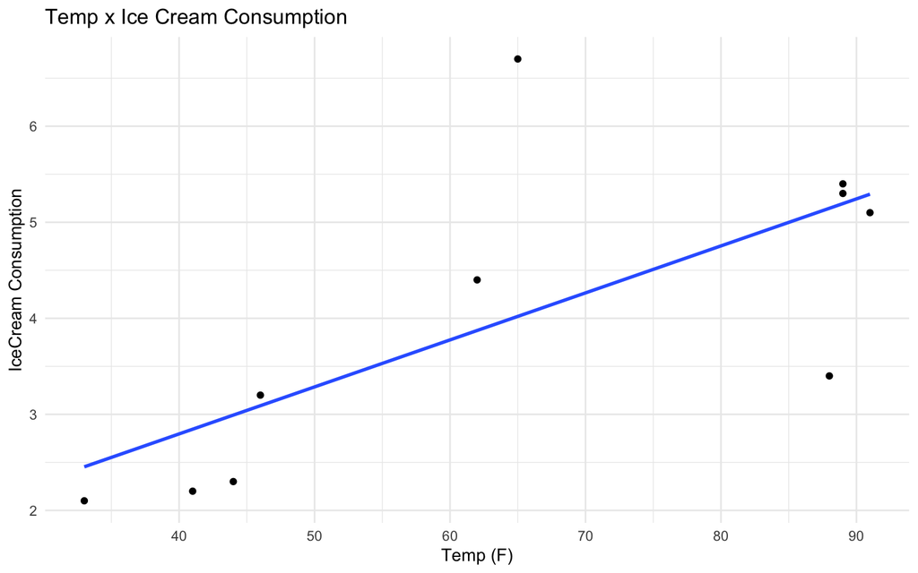

```r
ggplot(IceCream, aes(AverageTemperature, IceCreamConsumption)) +
  geom_point() +
  geom_smooth(method = "lm", se = FALSE) +
  theme_minimal() +
  labs(title = "Temp x Ice Cream Consumption",
       x = "Temp (F)", y = "IceCream Consumption")
```

## BONUS: APA Correlation table

### Downloads as a word document that you can edit.

*Note: You will want to save the file as a different name if you make edits to it in word, because when you re-knit this file it will overwrite any changes to the original file name.*

```r
library(apaTables)
apa.cor.table(IceCream, table.number = 1, filename = "ex.CorTable1.doc")
```

```
##
##
## Table 1
##
## Means, standard deviations, and correlations with confidence intervals
##
##
##   Variable               M     SD    1          2
##   1. IceCreamConsumption 4.01  1.60
##
##   2. CrimeRate           73.20 21.01 .74*
##                                      [.21, .94]
##
##   3. AverageTemperature  64.80 23.02 .70*       .66*
##                                      [.13, .92] [.04, .91]
##
##
## Note. M and SD are used to represent mean and standard deviation, respectively.
## Values in square brackets indicate the 95% confidence interval.
## The confidence interval is a plausible range of population correlations
## that could have caused the sample correlation (Cumming, 2014).
##  * indicates p < .05. ** indicates p < .01.
##
```

### Making a table for the PDF Markdown

```r
#https://stefaneng.github.io/apa_correlation_table/
library(Hmisc) # For rcorr
library(knitr) # Pretty print table
```

**Helper Function:** First we define a function that allows us to apply a function to each cell that satisfies a property.

```r
#' Applies a function `f` to each cell of a data frame `mat` if the corresponding cell in `p` is TRUE
#'
#' @param mat A matrix or data frame
#' @param p A matrix with the same dimension as `mat`
#' @param f A function to apply
#' @return `mat` with `f` applied to each cell where `p` is TRUE.
#' @examples
#' x <- rbind(c(1,2,3), c(4,5,6), c(7,8,9))
#' apply_if(x, upper.tri(x), function(x) x + 5)
apply_if <- function(mat, p, f) {
  # Fill NA with FALSE
  p[is.na(p)] <- FALSE
  mat[p] <- f(mat[p])
  mat
}
```

#### APA Correlation Matrix

Now we can define a function to return the matrix with the stars appended to significant correlations. The row names are kept with the index appended. The column names are replaced with the index.

```r
#' @param mat an rcorr object or a double matrix
#' @param corrtype is either pearson or spearman. Will be passed into Hmsic::rcorr if mat is not already an rcorr object
#' @return `mat` with stars appended for each level of significants (p < 0.05, p < 0.01, p < 0.001)
apaCorr <- function(mat, corrtype = "pearson") {
  matCorr <- mat
  if (class(matCorr) != "rcorr") {
    matCorr <- rcorr(mat, type = corrtype)
  }

  # Add one star for each p < 0.05, 0.01, 0.001
  stars <- apply_if(round(matCorr$r, 2), matCorr$P < 0.05, function(x) paste0(x, "*"))
  stars <- apply_if(stars, matCorr$P < 0.01, function(x) paste0(x, "*"))
  stars <- apply_if(stars, matCorr$P < 0.001, function(x) paste0(x, "*"))
  # Put - on diagonal and blank on upper diagonal
  stars[upper.tri(stars, diag = T)] <- "-"
  stars[upper.tri(stars, diag = F)] <- ""
  n <- length(stars[1,])
  colnames(stars) <- 1:n
  # Remove _ and convert to title case
  row.names(stars) <- tools::toTitleCase(sapply(row.names(stars), gsub, pattern="_", replacement = " "))
  # Add index number to row names
  row.names(stars) <- paste(paste0(1:n,"."), row.names(stars))
  stars
}
```

Example: Now we can use apaCorr and kable to pretty print the correlation table in a format similar to APA.

```r
pdf.table <- apaCorr(as.matrix(IceCream), corrtype = "pearson")
kable(pdf.table, format = "markdown")
```

|  | 1 | 2 | 3 |
| --- | --- | --- | --- |
| 1. IceCreamConsumption | - |  |  |
| 2. CrimeRate | 0.74* | - |  |
| 3. AverageTemperature | 0.7* | 0.66* | - |